# Basic data management

Jing Fang

# This lecture covers

- Manipulating missing values
- Understanding data type conversions
- Creating and recoding variables
- Sorting, merging, and subsetting datasets.
- Selecting and dropping variables.

# 4.1 A working example

# A working example

- Topic: How do men and women differ in the ways they lead their organizations.
- Typical questions:
  - Do men and women in management positions differ in the degree to which they defer to superiors?
  - Does this vary from country to country, or are these gender difference universal?
- One way to address these questions is to have bosses in multiple countries rate their managers on deferential behavior.

# A working example

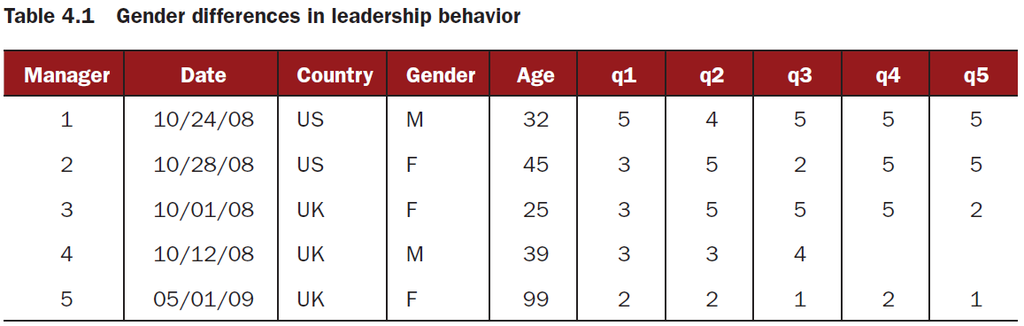

# A working example

- You can create a data frame containing the data in table 4.1 using the following code.

```r
manager <- c(1, 2, 3, 4, 5)
date <- c("10/24/08", "10/28/08", "10/1/08", "10/12/08", "5/1/09")
country <- c("US", "US", "UK", "UK", "UK")
gender <- c("M", "F", "F", "M", "F")
age <- c(32, 45, 25, 39, 99)
q1 <- c(5, 3, 3, 3, 2)
q2 <- c(4, 5, 5, 3, 2)
q3 <- c(5, 2, 5, 4, 1)
q4 <- c(5, 5, 5, NA, 2)
q5 <- c(5, 5, 2, NA, 1)
leadership <- data.frame(manager, date, country, gender, age, q1, q2, q3, q4,
    q5, stringsAsFactors = FALSE)
leadership
```

```
##   manager     date country gender age q1 q2 q3 q4 q5
## 1       1 10/24/08      US      M  32  5  4  5  5  5
## 2       2 10/28/08      US      F  45  3  5  2  5  5
## 3       3  10/1/08      UK      F  25  3  5  5  5  2
## 4       4 10/12/08      UK      M  39  3  3  4 NA NA
## 5       5   5/1/09      UK      F  99  2  2  1  2  1
```

# A working example

- In order to address the questions of interest, we must first address several data management issues.
  - q1 to q5 will need to be combined, yielding a single mean deferential score from each manager.
  - We’ll need a method of handling incomplete data.
  - To simplify matters, we’ll want to create a new dataset with only the variables of interest.
  - We may want to recode the current values of age into a new categorical age grouping.

# 4.2 Creating new variables

# Creating new variables

- In a typical research project, you’ll need to create new variables and transform existing ones.
- This is accomplished with statements of the form:
  - `variable <- expression`
- A wide array of operators and functions can be included in the `expression` portion of the statement.

# Creating new variables

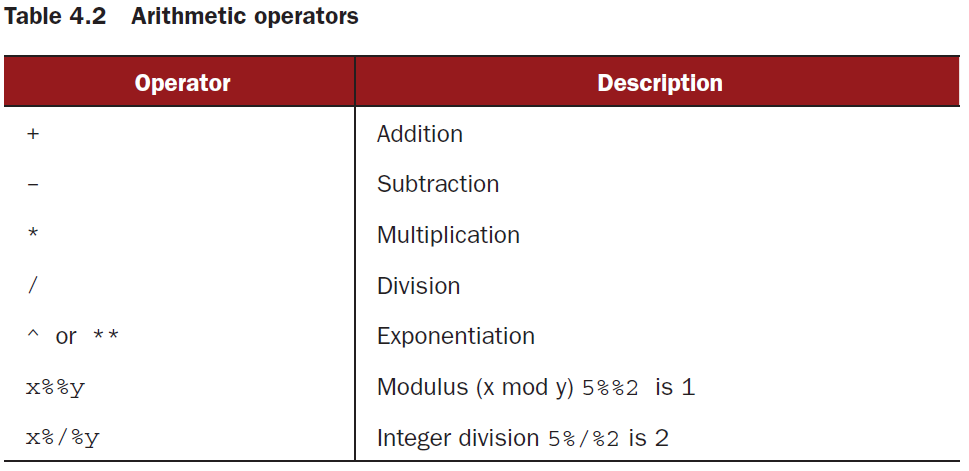

# Creating new variables

- Suppose you have a data frame named `mydata`, with variables `x1` and `x2`, and you want to create a new variable `sumx` that adds these two variables and a new variable called `meanx` that averages the two variables.
- If you use the code:

  ```r
  sumx = x1 + x2
  meanx = (x1 + x2)/2
  ```

  you will get an error, because R doesn’t know that `x1` and `x2` are from data frame mydata.

# Creating new variables

- You need to use this code instead:

  ```r
  sum = mydata$x1 + mydata$x2
  meanx = (mydata$x1 + mydata$x2)/2
  ```

- The statements will succeed but you’ll end up with a data frame (`mydata`) and two separate vectors (`sumx` and `meanx`). This is probably not what you want.

# Creating new variables

- The following listing provides two separate ways to incorporate new variables into the original data frame.

```r
mydata <- data.frame(x1 = c(2, 2, 6, 4), x2 = c(3, 4, 2, 8))

mydata$sumx <- mydata$x1 + mydata$x2
mydata$meanx <- (mydata$x1 + mydata$x2)/2

attach(mydata)
mydata$sumx <- x1 + x2
mydata$meanx <- (x1 + x2)/2
detach(mydata)
```

# 4.3 Recoding variables

# Recoding variables

- Recoding involves creating new values of a variable conditional on the existing values of the same and/or other variables.
- To recode data, you can use one or more of R’s logical operators.

# Recoding variables

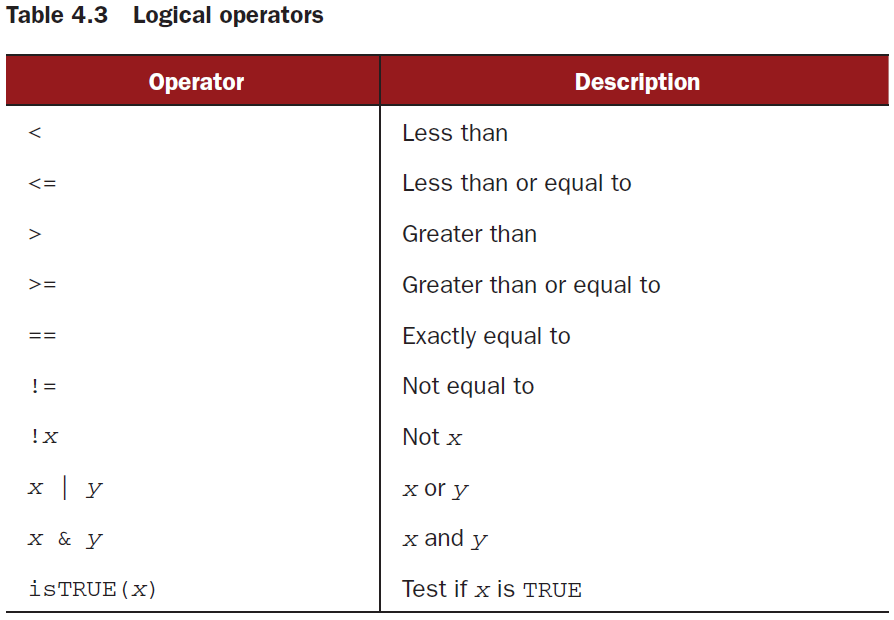

# Recoding variables

- Suppose you want to recode the ages of the managers in our leadership dataset from the continuous variable `age` to the categorical variable `agecat` (`Young`, `Middle Aged`, `Elder`).
- First, you must recode the value 99 for age to missing.

```r
leadership$age[leadership$age == 99] <- NA
```

- The statement `variable[condition] <- expression` will only make the assignment when `condition` is `TRUE`.

# Recoding variables

- You can then create the agecat variable:

  ```r
  leadership$agecat[leadership$age > 75] <- "Elder"
  leadership$agecat[leadership$age >= 55 & leadership$age <= 75] <- "Middle Aged"
  leadership$agecat[leadership$age < 55] <- "Young"
  ```

# Recoding variables

- This code can be written more compactly as:

  ```r
  leadership <- within(leadership, {
      agecat <- NA
      agecat[age > 75] <- "Elder"
      agecat[age >= 55 & age <= 75] <- "Middle Aged"
      agecat[age < 55] <- "Young"
  })
  ```

- The `within()` function is similar to the `with()` function, but allows you to modify the data frame.

# 4.4 Renaming variables

# Renaming variables

- If you’re not happy with your variable names, you can change them via the names() function. For example:

  ```r
  names(leadership)
  names(leadership)[2] <- "testDate"
  leadership
  ```

# 4.5 Missing values

# Missing values

- In a project of any size, data is likely to be incomplete because of missed questions, faulty equipment, or improperly coded data.
- In R, missing values are represented by the symbol NA.
- R provides a number of functions for identifying observations that contain missing values.
- The function `is.na()` allows you to test for the presence of missing values.

# Missing values

```r
is.na(leadership[, 6:10])
```

```
##         q1    q2    q3    q4    q5
## [1,] FALSE FALSE FALSE FALSE FALSE
## [2,] FALSE FALSE FALSE FALSE FALSE
## [3,] FALSE FALSE FALSE FALSE FALSE
## [4,] FALSE FALSE FALSE  TRUE  TRUE
## [5,] FALSE FALSE FALSE FALSE FALSE
```

# Excluding missing values from analysis

- Once you’ve identified the missing values, you need to eliminate them in some way before analyzing your data further.
- For example try the following code:

  ```r
  x <- c(1, 2, NA, 3)
  y <- x[1] + x[2] + x[3] + x[4]
  z <- sum(x)
  y
  ```

  ```
  ## [1] NA
  ```

  ```r
  z
  ```

  ```
  ## [1] NA
  ```

# Excluding missing values from analysis

- Luckily, most numeric functions have a `na.rm=TRUE` option that removes missing values prior to calculations and applies the function to the remain values:

  ```r
  x <- c(1, 2, NA, 3)
  y <- sum(x, na.rm = TRUE)
  y
  ```

  ```
  ## [1] 6
  ```

# Excluding missing values from analysis

- You can remove any observation with missing data by using the `na.omit()` funciton.

```r
leadership
```

```
##   manager     date country gender age q1 q2 q3 q4 q5 agecat
## 1       1 10/24/08      US      M  32  5  4  5  5  5  Young
## 2       2 10/28/08      US      F  45  3  5  2  5  5  Young
## 3       3  10/1/08      UK      F  25  3  5  5  5  2  Young
## 4       4 10/12/08      UK      M  39  3  3  4 NA NA  Young
## 5       5   5/1/09      UK      F  NA  2  2  1  2  1   <NA>
```

```r
newdata <- na.omit(leadership)
newdata
```

```
##   manager     date country gender age q1 q2 q3 q4 q5 agecat
## 1       1 10/24/08      US      M  32  5  4  5  5  5  Young
## 2       2 10/28/08      US      F  45  3  5  2  5  5  Young
## 3       3  10/1/08      UK      F  25  3  5  5  5  2  Young
```

# 4.6 Type conversions

# Type conversions

- Type conversions in R work in a similar fashion to those in other statistical programming languages.
- Functions of the form `is.datatype()` return TRUE or FALSE, whereas `as.datatype()` converts the argument to that type.

# Type conversions

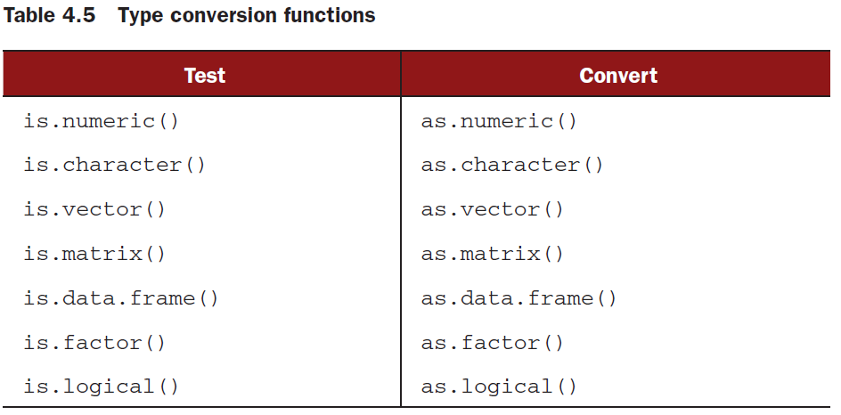

# Type conversions

```r
a <- c(1, 2, 3)
a
```

```
## [1] 1 2 3
```

```r
is.numeric(a)
```

```
## [1] TRUE
```

```r
is.vector(a)
```

```
## [1] TRUE
```

```r
a <- as.character(a)
a
```

```
## [1] "1" "2" "3"
```

```r
is.numeric(a)
```

```
## [1] FALSE
```

```r
is.vector(a)
```

```
## [1] TRUE
```

```r
is.character(a)
```

```
## [1] TRUE
```

# 4.7 Sorting data

# Sorting data

- Sometimes, viewing a dataset in a sorted order can tell you quite a bit about the data.
- To sort a data frame in R, use the `order()` function

```r
newdata <- leadership[order(leadership$age), ]

attach(leadership)
newdata <- leadership[order(gender, age), ]
newdata <- leadership[order(gender, -age), ]
detach(leadership)
```

# 4.8 Merging datasets

# Merging datasets

- If your data exist in multiple locations, you’ll need to combine them before moving forward.
- To merge two data frame horizontally, you use the merge function.
- In most cases, two data frames are joined by one or more common key variables.

  ```r
  total <- merge(A, B, by = "ID")
  total <- merge(A, B, by = c("ID", "Country"))
  ```

# Merging datasets

- If you don’t need to specify a common key, you can use the `cbind()` function.

  ```r
  total <- cbind(A, B)
  ```

- To join two data frames vertically, use the `rbind()` function.

  ```r
  total <- rbind(A, B)
  ```

- The two data frames must have the same variables, but they don’t have to be in the same order.

# 4.9 Subsetting datasets

# Subsetting datasets

- R has powerful indexing features for accessing the elements of an object.
- These features can be used to select and exclude variable, observations, or both.

# Selecting (keeping) variables

- It’s a common practice to create a new dataset from a limited number of variables chosen from a larger dataset.

# Excluding (dropping) variables

- You could exclude variables q3 and q4:

```r
myvars <- names(leadership) %in% c("q3", "q4")
newdata <- leadership[!myvars]

newdata <- leadership[c(-8, -9)]

leadership$q3 <- leadership$q4 <- NULL
```

# Selecting observations

- Selecting or excluding observations (rows) is typically a key aspect of successful data preparation and analysis.
- If you want to limit your analysis to observations who is male and older than 30. How can you do this?

# Selecting observations

```r
newdata <- leadership[which(leadership$gender == "M" & leadership$age > 30),
    ]

attach(leadership)
newdata <- leadership[which(gender == "M" & age > 30), ]
detach(leadership)
```

# The subset() function

- The `subset` function is probably the easiest way to select variables and observations.

```r
newdata <- subset(leadership, age >= 35 | age < 24, select = c(q1, q2, q3, q4))
newdata <- subset(leadership, gender == "M" & age > 25, select = gender:q4)
```

# Random samples

- Sampling from larger datasets is a common practice.
- The `sample()` function enables you to take a random sample of size n from a dataset.

  ```r
  mysample <- leadership[sameple(1:nrow(leadership), 3, replace = FALSE), ]
  ```